# Comparing seasonal and latitudinal patterns in thermal adaptation

### Local PCA and candidate inversions

Each clade’s genome was split into windows of 2,000 SNPs, and the population structure in each window (top two PCs of the covariance among individuals) was compared between all windows (lostruct; Li & Ralph 2019). Windows were then placed on MDS axes: most of the genome shares the same structure and clusters near zero; regions with distinct structure, such as inversions, stand out as runs of windows far from zero. Windows more than 4 robust SDs from the median are coloured.

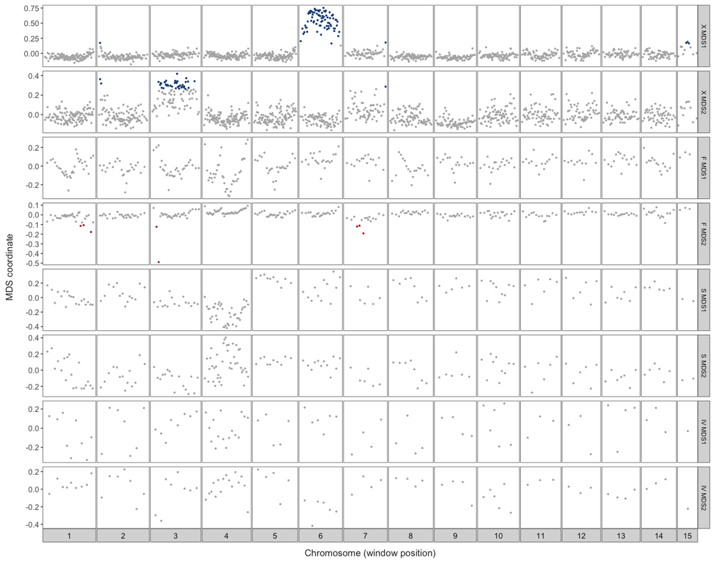

```r
lp_files <- Sys.glob(cx("results", "08_localpca", "*", "windows.tsv"))
fai_file <- cx("data", "reference", "genome", "reference.fa.fai")
if (length(lp_files) == 0) {
  cat("Local PCA is not in this export yet.")
} else {
  chrom_order <- if (file.exists(fai_file)) read_tsv(fai_file, col_names = FALSE, show_col_types = FALSE)$X1 else NULL
  lp <- map_dfr(lp_files, ~ read_tsv(.x, show_col_types = FALSE) %>%
                  mutate(clade = basename(dirname(.x)))) %>%
    filter(clade %in% tonsa_clades)
  if (is.null(chrom_order)) chrom_order <- unique(lp$chrom)
  chroms <- intersect(chrom_order, unique(lp$chrom))
  lp <- lp %>%
    mutate(chr = factor(match(chrom, chroms)),
           mid_mb = (start + end) / 2e6,
           clade = factor(clade, levels = tonsa_clades)) %>%
    pivot_longer(c(mds1, mds2), names_to = "axis", values_to = "mds") %>%
    group_by(clade, axis) %>%
    mutate(z = (mds - median(mds)) / mad(mds), outlier = abs(z) > 4) %>%
    ungroup() %>%
    mutate(row = factor(paste(clade, toupper(axis)),
                        levels = paste(rep(tonsa_clades, each = 2), c("MDS1", "MDS2"))))
  write_csv(lp, here("Output", "Output_data", "localpca_windows.csv"))
  ggplot(lp, aes(x = mid_mb, y = mds, colour = ifelse(outlier, as.character(clade), "none"))) +
    facet_grid(row ~ chr, scales = "free", space = "free_x", switch = "x") +
    geom_point(size = 0.7) +
    scale_colour_manual(values = c(clade_cols[tonsa_clades], none = "grey70"), guide = "none") +
    scale_x_continuous(breaks = NULL) +
    labs(x = "Chromosome (window position)", y = "MDS coordinate") +
    theme_matt_facets(base_size = 11) +
    theme(panel.spacing.x = unit(1, "pt"), strip.text.y = element_text(size = 9))
}
```

For each candidate region (at least 5 windows, mostly outliers), individuals are placed by their average PC1 score across the region’s windows. An inversion typically splits individuals into three groups (the two homozygous arrangements and the heterozygotes); a region tracking site or sub-lineage instead points to differentiation, and a few individuals far from everyone else to a rare variant arrangement or introgression.

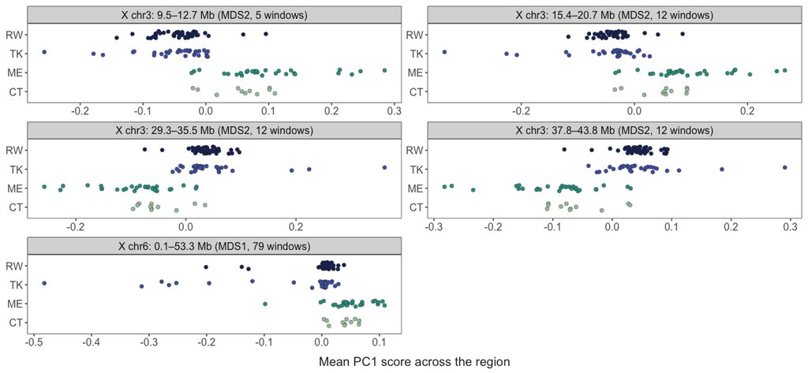

```r
if (length(lp_files) > 0) {
  # candidate regions: runs of windows where >= 60% of the 5 surrounding windows are
  # outliers; runs separated by up to 3 windows are merged
  fill_gaps <- function(x, gap = 3) {
    r <- rle(x)
    inner <- seq_along(r$values) > 1 & seq_along(r$values) < length(r$values)
    r$values[!r$values & r$lengths <= gap & inner] <- TRUE
    inverse.rle(r)
  }
  regions <- lp %>%
    arrange(clade, axis, chr, start) %>%
    group_by(clade, axis, chr) %>%
    mutate(dens = map_dbl(seq_along(outlier), ~ mean(outlier[max(1, .x - 2):min(length(outlier), .x + 2)])),
           inreg = fill_gaps(dens >= 0.6),
           run = cumsum(inreg != lag(inreg, default = FALSE))) %>%
    filter(inreg) %>%
    group_by(clade, axis, chr, run) %>%
    summarise(chrom = first(chrom), start = min(start), end = max(end), n_win = n(), .groups = "drop") %>%
    filter(n_win >= 5) %>%
    arrange(clade, as.integer(as.character(chr)), start) %>%
    mutate(label = sprintf("%s chr%s: %.1f–%.1f Mb (%s, %d windows)", clade, chr, start / 1e6, end / 1e6,
                           toupper(axis), n_win))
  write_csv(regions, here("Output", "Output_data", "localpca_candidate_regions.csv"))
  if (nrow(regions) == 0) {
    cat("No candidate regions (runs of at least 5 outlier windows).")
  } else {
    region_scores <- pmap_dfr(regions, function(clade, chrom, start, end, label, ...) {
      sc <- read_tsv(cx("results", "08_localpca", clade, "window_pc1_scores.tsv.gz"), show_col_types = FALSE)
      m <- sc %>% filter(chrom == !!chrom, start >= !!start, end <= !!end) %>% select(-chrom, -start, -end) %>% as.matrix()
      ref <- m[which.max(rowSums(abs(m))), ]
      m <- m * sign(apply(m, 1, function(x) cor(x, ref)))      # PC signs are arbitrary per window
      tibble(label = label, clade = clade, sample_id = colnames(m), score = colMeans(m))
    }) %>%
      left_join(select(seq_data, sample_id, site_code, season), by = "sample_id") %>%
      mutate(site_code = factor(site_code, levels = site_order),
             label = factor(label, levels = regions$label))
    ggplot(region_scores, aes(x = score, y = site_code, fill = site_code)) +
      facet_wrap(~ label, scales = "free", ncol = 2) +
      geom_jitter(shape = 21, size = 2, height = 0.2, width = 0, colour = "grey20", stroke = 0.2) +
      scale_fill_manual(values = pop_cols[site_order], guide = "none") +
      labs(x = "Mean PC1 score across the region", y = NULL) +
      theme_matt_facets(base_size = 12)
  }
}
```

#### Follow-up of the candidate regions

Each candidate region (and a control region on chromosome 1 with no local-PCA signal) was analysed on its own: a PCA of the region (PCAngsd), each individual’s heterozygosity inside the region relative to its genome-wide heterozygosity, and LD over distances up to 2 Mb. An inversion shows as groups on the regional PC1 with heterozygotes raised in heterozygosity (ratio above the bulk) and homozygotes for the rarer arrangement lowered; suppressed recombination raises long-range LD when both arrangements are common.

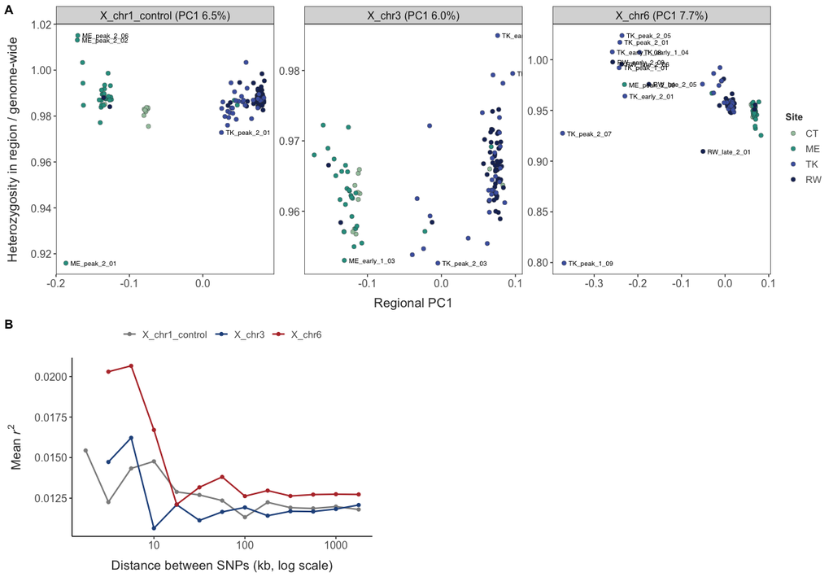

```r
reg_dirs <- Sys.glob(cx("results", "11_regions", "*"))
reg_dirs <- reg_dirs[file.exists(file.path(reg_dirs, "het.tsv"))]
if (length(reg_dirs) == 0) {
  cat("Candidate-region results are not in this export yet.")
} else {
  reg <- map_dfr(reg_dirs, function(d) {
    region <- basename(d)
    clade <- sub("_.*", "", region)
    ids <- readLines(cx("results", "02_sites", "bamlists", paste0(clade, ".ids.txt")))
    cv <- as.matrix(read.table(file.path(d, "pcangsd.cov")))
    e <- eigen(cv, symmetric = TRUE)
    het <- read_tsv(file.path(d, "het.tsv"), show_col_types = FALSE)
    tibble(region = region, sample_id = ids, PC1 = e$vectors[, 1], PC2 = e$vectors[, 2],
           pc1_pct = 100 * e$values[1] / sum(e$values)) %>%
      left_join(het, by = "sample_id")
  }) %>%
    left_join(select(seq_data, sample_id, site_code, season), by = "sample_id") %>%
    group_by(region) %>%
    mutate(PC1 = PC1 * sign(sum(PC1^3)) * -1,                      # put the minority group on the left
           z_het = (het_ratio - median(het_ratio)) / mad(het_ratio),
           # label a small group far from the rest on PC1 (< 15% of individuals), and the
           # 2 most extreme individuals for heterozygosity
           far = abs(PC1 - median(PC1)) > 0.15,
           label = if_else((far & mean(far) < 0.15) | rank(het_ratio) <= 2 | rank(-het_ratio) <= 2,
                           sample_id, NA_character_),
           panel = sprintf("%s (PC1 %.1f%%)", region, first(pc1_pct))) %>%
    ungroup() %>%
    mutate(site_code = factor(site_code, levels = site_order))
  write_csv(reg, here("Output", "Output_data", "candidate_regions_individuals.csv"))

  p_reg <- ggplot(reg, aes(x = PC1, y = het_ratio, fill = site_code)) +
    facet_wrap(~ panel, scales = "free", nrow = 1) +
    geom_point(shape = 21, size = 2.2, colour = "grey20", stroke = 0.2) +
    geom_text(aes(label = label), size = 2.6, hjust = -0.1, vjust = 0.5, na.rm = TRUE) +
    scale_fill_manual(values = pop_cols[site_order], drop = TRUE) +
    labs(x = "Regional PC1", y = "Heterozygosity in region / genome-wide", fill = "Site") +
    theme_matt_facets(base_size = 12)

  reg_ld <- map_dfr(reg_dirs, ~ read_tsv(file.path(.x, "ld_bins.tsv"), show_col_types = FALSE) %>%
                      mutate(region = basename(.x))) %>%
    filter(n_pairs >= 50)
  p_ld <- ggplot(reg_ld, aes(x = min_bp / 1000, y = mean_r2_ExpG, colour = region)) +
    geom_line(linewidth = 0.8) + geom_point(size = 1.5) +
    scale_x_log10() +
    scale_colour_manual(values = c("grey55", "#24518B", "#B73534")) +
    labs(x = "Distance between SNPs (kb, log scale)", y = expression(Mean~italic(r)^2), colour = NULL) +
    theme_matt(base_size = 12)

  ggarrange(p_reg, ggarrange(p_ld, NULL, widths = c(1, 1.2)), nrow = 2, heights = c(1.2, 1), labels = c("A", "B"))
}
```

**Chromosome 6 (X)** fits a rare chromosomal variant such as an inversion. A minority of individuals, almost all from St. Thomas de Kent Wharf and a few from Ritchie Wharf, sits apart on the regional PC1. Most of them are about 5% more heterozygous on chromosome 6 than their genome-wide average, as expected for heterozygous carriers, while the two most extreme individuals (TK_peak_1_09, TK_peak_2_07) are less heterozygous, as expected for homozygotes of the rare arrangement. At this frequency (roughly 5% of chromosomes overall) LD across the whole sample is raised only slightly (panel B: higher at short distances and marginally at 0.1–2 Mb than on the control chromosome). **Chromosome 3 (X)** does not: individuals split by site as on the control chromosome, with no heterozygosity classes; only two or three TK early individuals stand out on PC2 with slightly raised heterozygosity, which could be a smaller rare variant within the region.

### Parasites and symbionts

Reads that did not map to the *A. tonsa* reference were screened for small-subunit rRNA (phyloFlash, SILVA 138.1). Each read pair was assigned to the shared ancestor of all equally good database hits, at a rank limited by its identity, and host (*Acartia*) rRNA was removed. An organism group was called present at ≥ 5 read pairs and ≥ 2 per million library pairs (`Scripts/04_micro_calls.R`). Parasites (*Paradinium*, trematodes) and epibionts (apostome and peritrich ciliates) show strong site × season patterns: apostomes in every Connecticut late-season individual, trematodes in most Ritchie Wharf peak-season individuals, and *Zoothamnium* on late-season Maine and St. Thomas de Kent Wharf copepods.

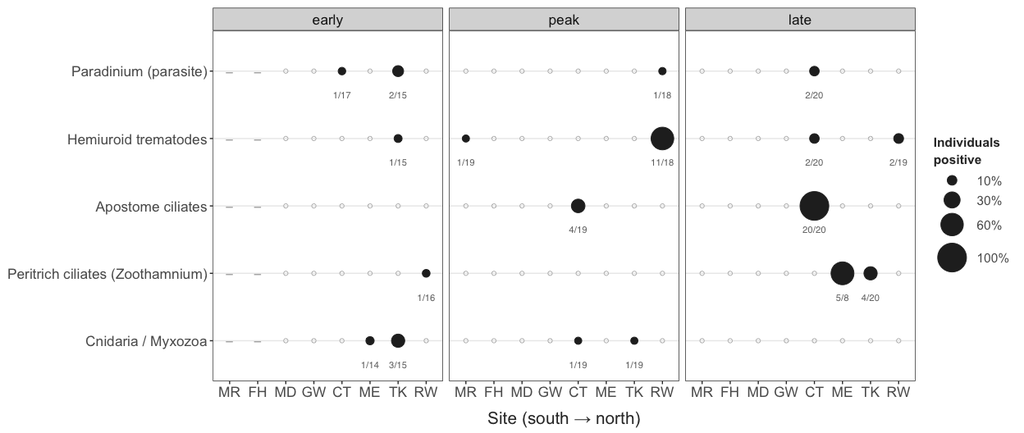

```r
prev_plot(micro_prev(main_groups))
```

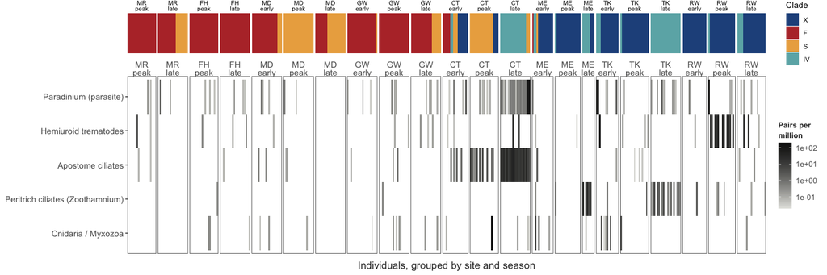

```r
strip_plot(main_groups)
```

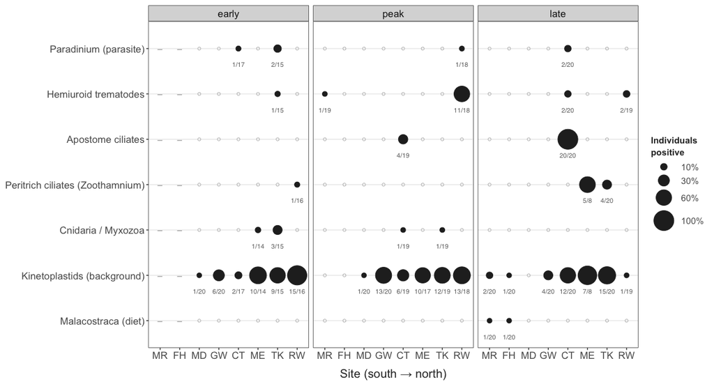

```r
prev_plot(micro_prev(all_groups))
```

### Seasonal allele-frequency change

Allele frequencies per population at the unlinked SNP set (one SNP per 10 kb; Section 3.2, LD) were compared between seasons within each site. Temporal differentiation is Nei & Tajima’s F<sub>c</sub> ([Nei & Tajima 1981](https://doi.org/10.1093/genetics/98.3.625)) over SNPs with ≥ 5 individuals with data in both samples and a mean minor-allele frequency of 0.05–0.95. Under the temporal method, F<sub>c</sub> ≈ t/(2N<sub>e</sub>) + sampling noise of both samples, so N<sub>e</sub> follows once the sampling noise is subtracted ([Waples 1989](https://doi.org/10.1093/genetics/121.2.379); [Jorde & Ryman 2007](https://doi.org/10.1534/genetics.107.075481)).

**Calibrating sampling noise.** With < 1× coverage, frequencies are sampled twice, once through the individuals and once through the reads, so an individual contributes less than two chromosomes of information ([Jónás et al. 2016](https://doi.org/10.1534/genetics.116.191197)). Pool-seq studies handle this with an “effective number of chromosomes” ([Feder et al. 2012](https://doi.org/10.1371/journal.pone.0048588); [Bergland et al. 2014](https://doi.org/10.1371/journal.pgen.1004775); [Machado et al. 2021](https://doi.org/10.7554/eLife.67577)). Here it was measured directly: each population was split at random into two halves (two replicates), allele frequencies were estimated for each half, and F<sub>c</sub> between the halves (pure sampling noise) was compared with the 1/(2n) expectation. The ratio, c, is the effective number of chromosomes per individual divided by two, and the sampling term for any sample becomes 1/(2cn). This split-half calibration is an empirical resampling check rather than a named published method.

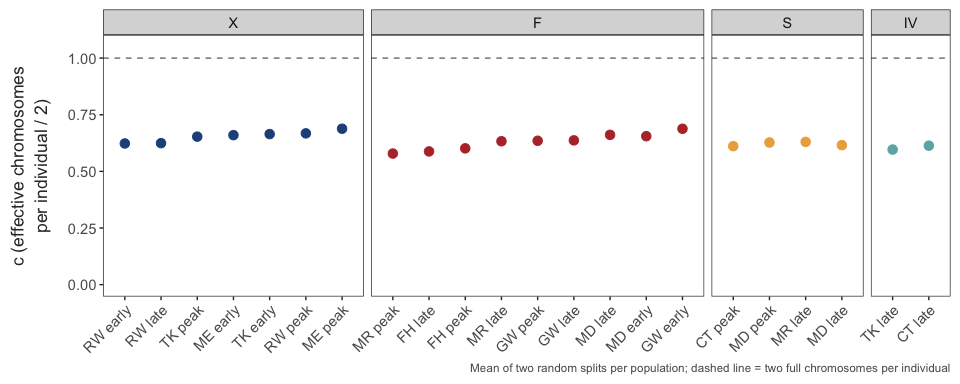

```r
split_half <- read_cx("results", "12_split", "split_half.tsv")
if (is.null(split_half)) {
  cat("Split-half calibration is not in this export yet.")
} else {
  c_pop <- split_half %>%
    group_by(population) %>%
    summarise(c = mean(c), c_diff = abs(diff(range(c))), n = mean(mean_n_a + mean_n_b), .groups = "drop") %>%
    separate(population, c("clade", "site", "season"), sep = "__", remove = FALSE) %>%
    filter(clade %in% tonsa_clades) %>%
    mutate(clade = factor(clade, levels = tonsa_clades),
           label = paste(site, season))
  ggplot(c_pop, aes(x = reorder(label, c), y = c, colour = clade)) +
    geom_hline(yintercept = 1, linetype = "dashed", colour = "grey50") +
    geom_point(size = 3) +
    facet_grid(. ~ clade, scales = "free_x", space = "free_x") +
    scale_colour_manual(values = clade_cols[tonsa_clades], guide = "none") +
    scale_y_continuous(limits = c(0, 1.05)) +
    labs(x = NULL, y = "c (effective chromosomes\nper individual / 2)",
         caption = "Mean of two random splits per population; dashed line = two full chromosomes per individual") +
    theme_matt_facets(base_size = 11) +
    theme(axis.text.x = element_text(angle = 45, hjust = 1))
}
```

Every population gives c ≈ 0.6–0.7 (about 1.2–1.4 effective chromosomes per individual), and the two random splits agree to within 0.02. The calibration is therefore stable and similar across clades, sites and seasons.

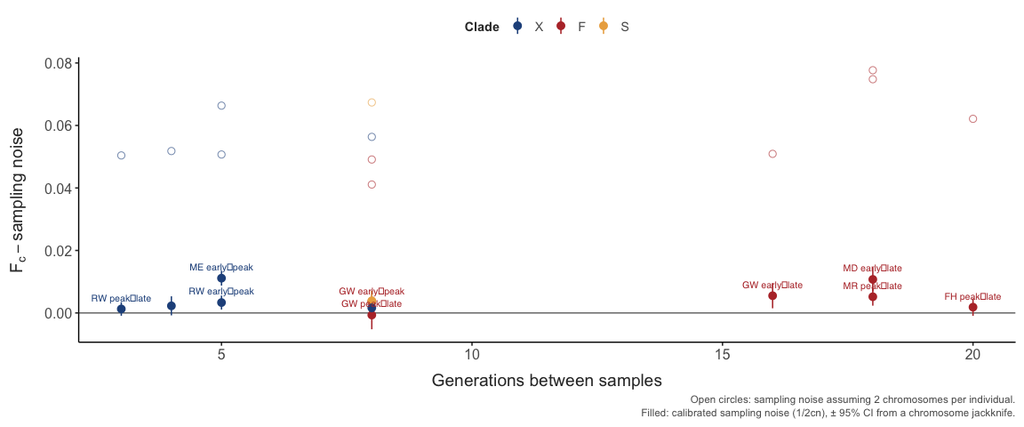

```r
freq_files <- Sys.glob(cx("results", "09_stage34", "*.freqs.unlinked.tsv.gz"))
if (length(freq_files) == 0 || !exists("generations") || is.null(split_half)) {
  cat("Allele-frequency tables or the split-half calibration are not in this export yet.")
} else {
  season_lv <- c("early", "peak", "late")
  c_of <- setNames(c_pop$c, c_pop$population)
  gens_tab <- generations %>% ungroup() %>%
    left_join(distinct(site_data, site, site_code), by = "site") %>%
    select(site_code, season, gens)
  gens_between <- function(site, s1, s2) {
    steps <- c("early_to_peak", "peak_to_late")[match(s1, season_lv):(match(s2, season_lv) - 1)]
    g <- gens_tab$gens[gens_tab$site_code == site & gens_tab$season %in% steps]
    if (length(g) == length(steps)) sum(g) else NA_real_
  }
  # Fc, uncalibrated (2 chromosomes per individual) and calibrated sampling terms, and
  # a delete-one-chromosome jackknife SE of the calibrated excess
  fc_pair <- function(m, a, b, min_n = 5) {
    x <- m[[paste0("freq_", a)]]; y <- m[[paste0("freq_", b)]]
    na <- m[[paste0("nind_", a)]]; nb <- m[[paste0("nind_", b)]]
    z <- (x + y) / 2
    ok <- !is.na(x) & !is.na(y) & na >= min_n & nb >= min_n & z >= 0.05 & z <= 0.95
    x <- x[ok]; y <- y[ok]; z <- z[ok]; na <- na[ok]; nb <- nb[ok]; ch <- m$chrom[ok]
    excess <- function(k) sum((x[k] - y[k])^2) / sum(z[k] - x[k] * y[k]) -
      mean(1 / (2 * c_of[[a]] * na[k]) + 1 / (2 * c_of[[b]] * nb[k]))
    jk <- map_dbl(unique(ch), ~ excess(ch != .x)); g <- length(jk)
    Fc <- sum((x - y)^2) / sum(z - x * y)
    tibble(snps = sum(ok), Fc = Fc,
           sampling_2n = mean(1 / (2 * na) + 1 / (2 * nb)),
           sampling_cal = Fc - excess(rep(TRUE, length(x))),
           excess = Fc - sampling_cal,
           se = sqrt((g - 1) / g * sum((jk - mean(jk))^2)))
  }
  temporal <- map_dfr(freq_files, function(f) {
    clade <- sub("\\.freqs.*", "", basename(f))
    m <- read_tsv(f, show_col_types = FALSE, col_types = cols(chrom = "c"))
    pops <- sub("^freq_", "", grep("^freq_", names(m), value = TRUE))
    combn(pops, 2, simplify = FALSE) %>% map_dfr(function(p) {
      a <- str_split_1(p[1], "__"); b <- str_split_1(p[2], "__")
      if (a[2] != b[2]) return(NULL)                       # seasonal pairs only
      ord <- order(match(c(a[3], b[3]), season_lv)); pp <- p[ord]
      s <- c(a[3], b[3])[ord]
      bind_cols(tibble(clade = clade, site = a[2], from = s[1], to = s[2],
                       gens = gens_between(a[2], s[1], s[2])),
                fc_pair(m, pp[1], pp[2]))
    })
  }) %>%
    mutate(ne = if_else(excess > 0, gens / (2 * excess), Inf),
           ne_lo = gens / (2 * (excess + 1.96 * se)),
           ne_hi = if_else(excess - 1.96 * se > 0, gens / (2 * (excess - 1.96 * se)), Inf),
           clade = factor(clade, levels = tonsa_clades),
           pair = paste0(site, " ", from, "→", to))
  write_csv(temporal, here("Output", "Output_data", "temporal_fc.csv"))

  p_exc <- temporal %>%
    mutate(uncal = Fc - sampling_2n) %>%
    ggplot(aes(x = gens, colour = clade)) +
    geom_hline(yintercept = 0, colour = "grey50") +
    geom_point(aes(y = uncal), shape = 1, size = 2.5, alpha = 0.6) +
    geom_pointrange(aes(y = excess, ymin = excess - 1.96 * se, ymax = excess + 1.96 * se), size = 0.5) +
    geom_text(aes(y = excess, label = pair), size = 2.8, vjust = -1.2, check_overlap = TRUE, show.legend = FALSE) +
    scale_colour_manual(values = clade_cols[tonsa_clades]) +
    labs(x = "Generations between samples", y = expression(F[c] - "sampling noise"),
         colour = "Clade",
         caption = "Open circles: sampling noise assuming 2 chromosomes per individual.\nFilled: calibrated sampling noise (1/2cn), ± 95% CI from a chromosome jackknife.") +
    theme_matt(base_size = 12)
  p_exc
}
```